# GC Content

Samuel Barreto

2017-02-24

# But du café

Le but de ce café est de vous montrer qu’on peut rendre une analyse de données entièrement reproductible par un tiers grâce aux outils développés par la communauté de développeurs R.

L’un des outils important dans cet écosystème est le package `knitr`, qui permet de transformer un document RMarkdown comme le présent document en un joli fichier html, que vous pouvez envoyer à vos chefs et qui les rendra très heureux.

En bref, `knitr` permet de produire des rapports en mélant du texte comme celui-ci avec du code. Le texte suit le format `markdown`, un format très simple de texte décrit brièvement [ici](https://www.rstudio.com/wp-content/uploads/2015/02/rmarkdown-cheatsheet.pdf).

Par exemple, on peut saisir des listes :

- coucou,
- cuicui,
- hello.

On peut écrire en *italique* ou en **gras**, utiliser une `police à chasse fixe`,

> On peut citer des gens ou mettre des phrases en exergue (<- joli mot non ?).

Les résultats du code seront ensuite directement intégrés au rapport, qu’on peut exporter au format `pdf` ou `html`. On peut produire des jolies pages dans [ce style](https://rawgit.com/juba/rmdformats/master/resources/examples/material/material.html).

Pour illustrer les capacités de `knitr`, on va s’intéresser à des données rendues disponibles par le NCBI, des informations générales sur les génomes procaryotes disponibles.

# Analyse du taux de GC des prokaryotes

Ce script analyse les données de génome téléchargées depuis le server FTP du NCBI. On ne s’intéresse ici qu’aux procaryotes.

L’idée est de regarder la diversité du taux de GC chez les procaryotes. Un truc qui n’intéresse bien que moi.

Vous pouvez jeter un œil aux données ici : http://www.ncbi.nlm.nih.gov/genome/browse/.

```r
library(tidyverse)
# pour faire des jolis graphiques.
library(hrbrthemes)
# pour changer les niveaux de facteurs dans une colonne.
# vous verrez c'est génial.
library(forcats)

# change le theme par défault.
theme_set(hrbrthemes::theme_ipsum_rc())
```

Maintenant qu’on s’est créé un bon environnement de travail, on va télécharger les données (2.8Mb).

```r
file <- paste0("../data-raw/", Sys.Date(), "_prokaryotes.tsv")

# si le fichier n'existe pas déjà,
if (!file.exists(file)) {
    #  télécharge le à l'adresse `url`
    download.file(url = "https://www.ncbi.nlm.nih.gov/genomes/Genome2BE/genome2srv.cgi?action=download&orgn=&report=proks&status=50|%3Bnopartial|noanomalous|&group=--%20All%20Prokaryotes%20--&subgroup=--%20All%20Prokaryotes%20--&format=",
                  # enregistre dans le fichier `file`.
                  destfile = file)
}
```

Maintenant que les données sont téléchargées, on va les importer grâce à cette bonne vieille fonction `read_delim`.

```r
dataset <- read_delim(file, "\t") %>%
    # nettoie les noms de colonnes qui sont un peu étrange
    janitor::clean_names()

dataset <-
    dataset %>%
    rename(organism = x_organism_name)
```

## Nombre de génomes par sous-groupe bactérien

Il doit certainement y avoir un échantillonage biaisé, les bactéries les plus pertinentes médicalement sont celles qui ont le plus de génomes séquencés.

Comptons donc le nombre de génomes par sous-groupe.

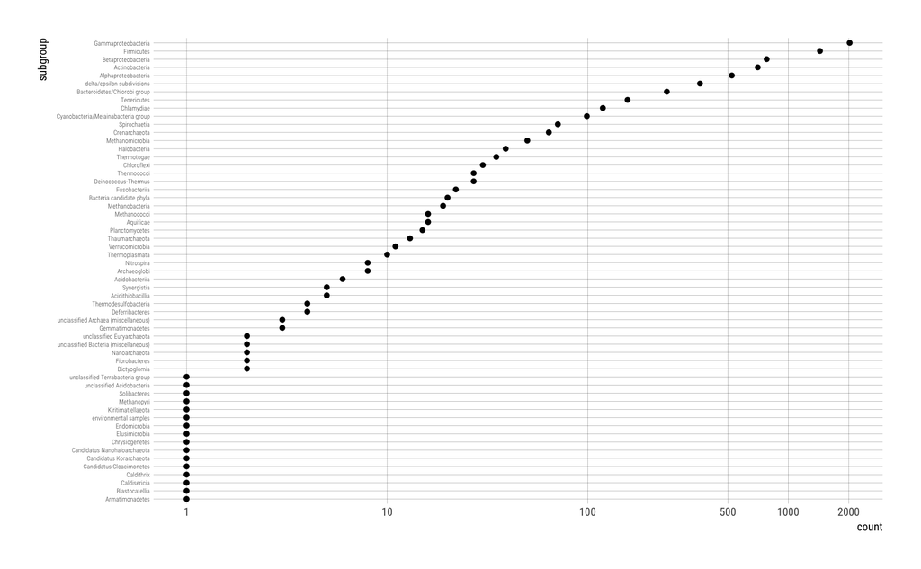

```r
dataset %>%
    group_by(subgroup) %>%
    # compte le nombre de génomes par sous-groupe.
    summarise(count = n()) %>%
    # là on peut voir à quoi sert le package forcats.
    # on réarrange la colonne subgroup en fonction de la valeur
    # présente dans la colonne count.
    mutate(subgroup = fct_reorder(subgroup, count)) %>%
    ggplot(aes(x = subgroup, y = count)) +
    geom_point() +
    scale_y_log10(breaks = c(1, 10, 100, 500, 1000, 2000, 5000, 1e4)) +
    coord_flip() +
    theme(axis.text.y = element_text(family = font_rc_light, size = 5),
          panel.grid.minor.x = element_blank())
```

## Relation entre nombre de gènes et taux de GC ?

Peut-on voir une corrélation entre le nombre de gènes dans un génome et son taux de GC ?

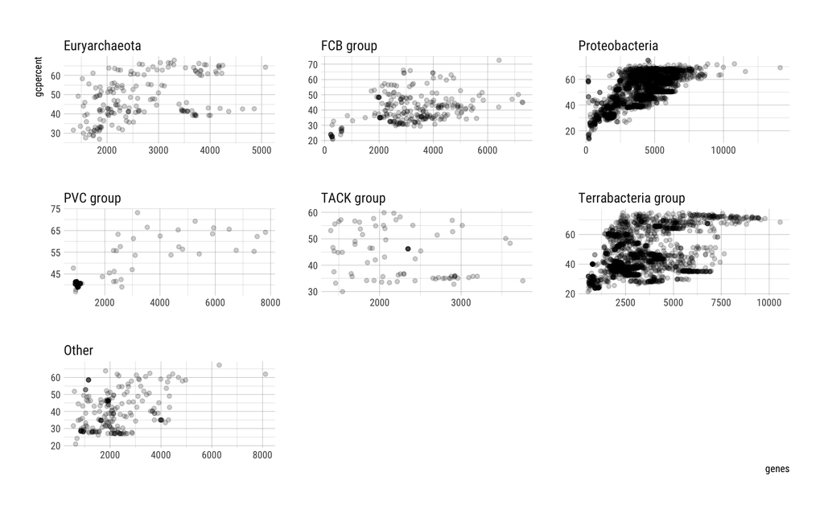

```r
dataset %>%
    # encore un chouette truc du package forcats:
    # crée 7 niveaux de facteurs pour les 6 groupes les plus fréquents
    # et compte tous les autres comme "Other".
    mutate(group = fct_lump(group, 6)) %>%
    ggplot(aes(x = genes, y = gcpercent)) +
    geom_point(alpha = 0.2) +
    facet_wrap( ~ group, scales = "free")
```

## Relation entre taille du génome et taux de GC ?

Est-ce qu’il n’y aurait pas un facteur confondant là-derrière ? Le nombre de gène doit être bien corrélé avec la taille du génome.

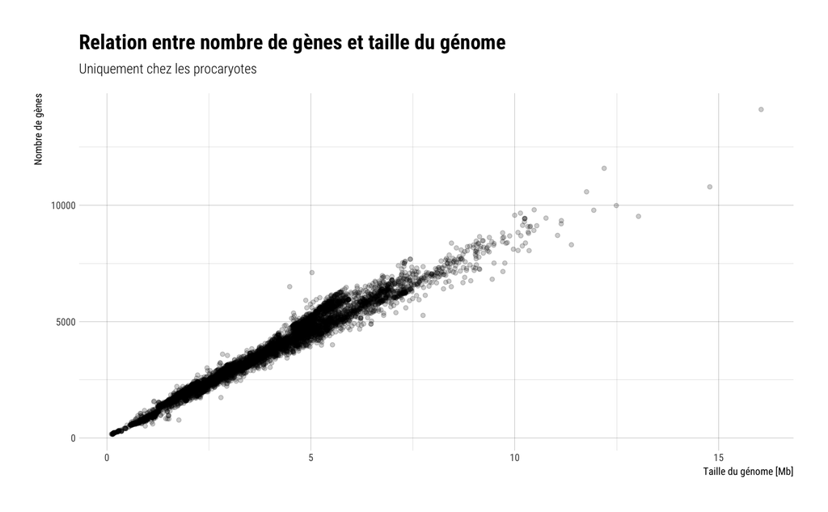

```r
dataset %>%
    ggplot(aes(size_mb, genes)) +
    geom_point(alpha = 2/10) +
    labs(x = "Taille du génome [Mb]",
         y = "Nombre de gènes",
         title = "Relation entre nombre de gènes et taille du génome",
         subtitle = "Uniquement chez les procaryotes")
```

Ok donc s’il y a une corrélation entre nombre de gènes et GC%, ça vient peut-être d’une relation entre taille du génome et taux de GC% …

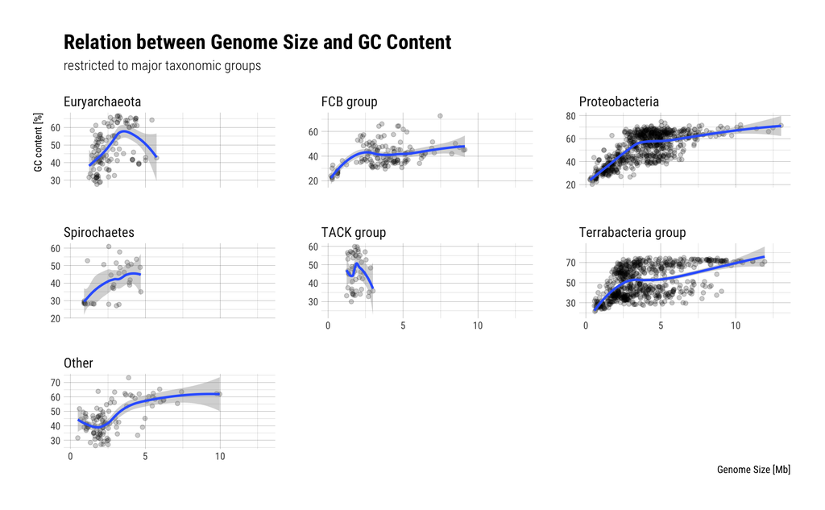

```r
dataset %>%
    group_by(cladeid) %>%
    slice(1) %>%
    ungroup() %>%
    mutate(group = fct_lump(group, 6)) %>%
    ggplot(aes(x = size_mb, y = gcpercent)) +
    geom_point(alpha = 2/10) +
    geom_smooth() +
    facet_wrap(~group, scales = "free_y") +
    labs(x = "Genome Size [Mb]",
         y = "GC content [%]",
         title = "Relation between Genome Size and GC Content",
         subtitle = "restricted to major taxonomic groups")
```

## Distribution du taux de GC dans les génomes séquencés

On échantillonne un représentant de chaque `CladeID` (un identifiant taxonomique unique par espèce) pour éviter de représenter deux fois des génomes d’une même espèce, et on représente la distribution du taux de GC. La couleur des barres représente le groupe taxonomique.

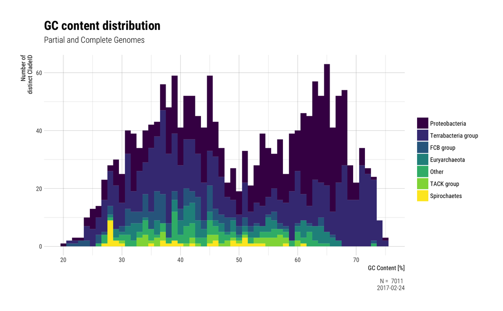

```r
dataset %>%
    group_by(cladeid) %>%
    slice(1) %>%
    # summarise(count = n()) %>%
    # arrange(desc(count)) %>%
    # full_join(select(dataset, taxid, organism), by = "taxid") %>%
    # arrange(desc(count))
    ungroup() %>%
    mutate(group = forcats::fct_lump(group, n = 6),
           group = forcats::fct_infreq(group)) %>%
    ggplot(aes(x = gcpercent)) +
    stat_bin(binwidth = 1, aes(fill = group)) +
    viridis::scale_fill_viridis(discrete = TRUE, begin = 0, end = 1,
                                guide = guide_legend(title = "")) +
    scale_x_continuous(breaks = seq(0, 81, 10)) +
    labs(x= "GC Content [%]",
         y= "Number of\ndistinct CladeID",
         title = "GC content distribution",
         subtitle = "Partial and Complete Genomes",
         caption = paste("N = ", nrow(dataset), "\n", Sys.Date()))
```

On voit que le taux de GC est très variable, et que cette variabilité est représentée dans tout les groupes taxonomiques majeurs. La distribution a une forme bimodale très curieuse qui semble indépendante d’un biais d’échantillonnage.